# Homework 06

## Question 1: Compare KNN and logistic regression

Use breast-cancer.csv, which contains 569 cases from the [Wisconsin Diagnostic Breast Cancer dataset](https://archive.ics.uci.edu/dataset/17/breast%2Bcancer%2Bwisconsin%2Bdiagnostic). Predict `y` (1 for malignant and 0 for benign) using `mean_radius`, `mean_texture`, and `mean_smoothness`.

Set a random seed and randomly split the observations into 70% training and 30% test data. Use the same split for every model. Standardize the predictors using the training means and standard deviations, and apply the same transformations to the test data.

Fit ordinary logistic regression with an intercept and no penalty, and KNN with Euclidean distance, equal neighbor weights, and

$$k\in\{5,15,25,35,45\}.$$

Using the estimated probabilities for `y = 1` on the test data, plot all six ROC curves in one figure and report their AUC values. Which of the six fitted models do you prefer? Give a brief justification based on your results.

### Answer

I wrote the KNN classifier myself so that the estimated probability of `y = 1` is the fraction of the $k$ nearest training observations that are malignant. The same distance matrix is reused for every $k$.

```r
bc <- read.csv("data/breast-cancer.csv")
predictors <- c("mean_radius", "mean_texture", "mean_smoothness")

set.seed(43206)
n <- nrow(bc)
train_id <- sample(n, round(0.7 * n))          # 70% training, 30% test
train <- bc[train_id, ]
test  <- bc[-train_id, ]
c(n_train = nrow(train), n_test = nrow(test), malignant_rate = mean(train$y))
```

```
       n_train         n_test malignant_rate
    398.000000     171.000000       0.361809
```

```r
# standardize with TRAINING means and standard deviations, applied to both sets
center <- colMeans(train[, predictors])
scale_ <- apply(train[, predictors], 2, sd)
Z_train <- scale(train[, predictors], center = center, scale = scale_)
Z_test  <- scale(test[, predictors],  center = center, scale = scale_)

# ROC curve and AUC from estimated probabilities (AUC via the Mann-Whitney identity)
roc_curve <- function(prob, y) {
  o <- order(prob, decreasing = TRUE); y <- y[o]
  list(fpr = c(0, cumsum(y == 0) / sum(y == 0)),
       tpr = c(0, cumsum(y == 1) / sum(y == 1)))
}
auc_value <- function(prob, y) {
  r <- rank(prob); n1 <- sum(y == 1); n0 <- sum(y == 0)
  (sum(r[y == 1]) - n1 * (n1 + 1) / 2) / (n1 * n0)
}

# KNN probability that y = 1: the fraction of the k nearest neighbours that are malignant
knn_prob <- function(D, y_train, k) apply(D, 1, function(d) mean(y_train[order(d)[1:k]]))

# rows = test observations, columns = training observations
D_test <- as.matrix(dist(rbind(Z_train, Z_test)))[nrow(Z_train) + seq_len(nrow(Z_test)),
                                                  seq_len(nrow(Z_train))]
```

```r
logit_fit <- glm(y ~ ., data = data.frame(Z_train, y = train$y), family = binomial)
p_logit   <- predict(logit_fit, newdata = data.frame(Z_test), type = "response")

ks <- c(5, 15, 25, 35, 45)
p_knn <- sapply(ks, function(k) knn_prob(D_test, train$y, k))
colnames(p_knn) <- paste0("k=", ks)

auc_all <- c(Logistic = auc_value(p_logit, test$y),
             apply(p_knn, 2, auc_value, y = test$y))
round(auc_all, 4)
```

```
Logistic      k=5     k=15     k=25     k=35     k=45
  0.9759   0.9438   0.9621   0.9697   0.9757   0.9764
```

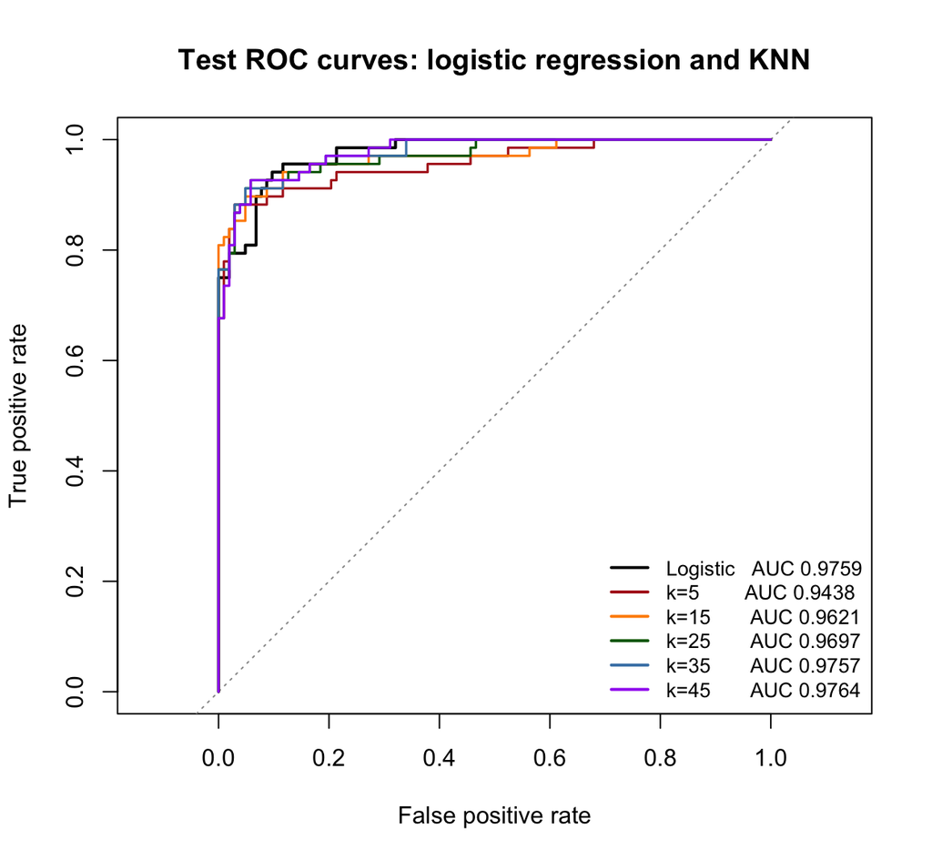

```r
cols <- c("black", "firebrick", "darkorange", "darkgreen", "steelblue", "purple")
plot(0:1, 0:1, type = "n", xlab = "False positive rate", ylab = "True positive rate",
     main = "Test ROC curves: logistic regression and KNN", asp = 1)
abline(0, 1, lty = 3, col = "grey60")
r <- roc_curve(p_logit, test$y)
lines(r$fpr, r$tpr, col = cols[1], lwd = 2)
for (j in seq_along(ks)) {
  r <- roc_curve(p_knn[, j], test$y)
  lines(r$fpr, r$tpr, col = cols[j + 1], lwd = 1.6)
}
legend("bottomright", bty = "n", lwd = 2, col = cols, cex = 0.85,
       legend = sprintf("%-10s AUC %.4f", names(auc_all), auc_all))
```

Table 1: Test AUC for the six fitted models.

| Model | AUC |
| --- | --- |
| Logistic regression | 0.9759 |
| 5NN | 0.9438 |
| 15NN | 0.9621 |
| 25NN | 0.9697 |
| 35NN | 0.9757 |
| 45NN | 0.9764 |

Second, the KNN curve is still improving at the largest $k$ tested, so $k=45$ is not a tuned optimum; it is the edge of the given grid, and a fair comparison would require selecting $k$ by cross-validation on the training data. Logistic regression reaches comparable accuracy with three slopes and an intercept, gives continuous probability estimates rather than multiples of $1/k$, and is directly interpretable through its coefficients. With this sample size and these three predictors, the extra flexibility of KNN buys nothing.

## Question 2: Training and test ROC curves

Use the same data, training/test split, and standardization as in Question 1. Fit KNN with Euclidean distance, equal neighbor weights, and

$$k\in\{1,3,5,10,20\}.$$

Use each fitted model to estimate probabilities for both the training and test observations. For training predictions, include each observation itself among its $k$ nearest neighbors.

For each $k$, use a separate panel to show the training and test ROC curves together. Report both AUC values.

Explain the difference between training and test performance and how it changes with $k$. In particular, explain what happens at $k=1$ and why training performance may not reflect performance on new observations.

### Answer

```r
ks2 <- c(1, 3, 5, 10, 20)

# training predictions: each observation is its own first neighbour (distance 0)
D_train <- as.matrix(dist(Z_train))

p_tr <- sapply(ks2, function(k) knn_prob(D_train, train$y, k))
p_te <- sapply(ks2, function(k) knn_prob(D_test,  train$y, k))
colnames(p_tr) <- colnames(p_te) <- paste0("k=", ks2)

auc_tab <- data.frame(
  k        = ks2,
  train_AUC = apply(p_tr, 2, auc_value, y = train$y),
  test_AUC  = apply(p_te, 2, auc_value, y = test$y))
auc_tab$gap <- auc_tab$train_AUC - auc_tab$test_AUC
round(auc_tab, 4)
```

```
      k train_AUC test_AUC    gap
k=1   1    1.0000   0.8900 0.1100
k=3   3    0.9893   0.9427 0.0467
k=5   5    0.9863   0.9438 0.0425
k=10 10    0.9844   0.9557 0.0287
k=20 20    0.9826   0.9602 0.0224
```

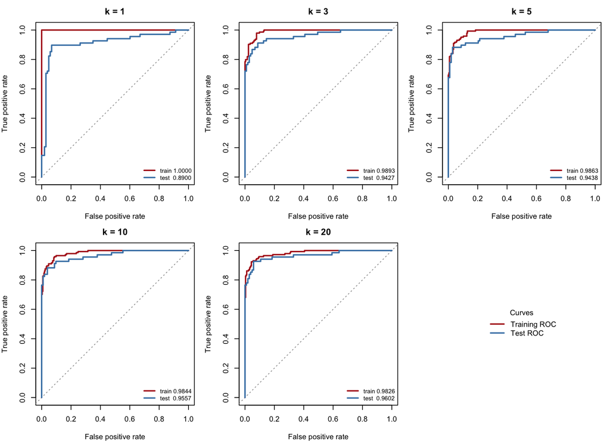

```r
op <- par(mfrow = c(2, 3), mar = c(4, 4, 2.5, 1))
for (j in seq_along(ks2)) {
  plot(0:1, 0:1, type = "n", xlab = "False positive rate", ylab = "True positive rate",
       main = sprintf("k = %d", ks2[j]), asp = 1)
  abline(0, 1, lty = 3, col = "grey60")
  r <- roc_curve(p_tr[, j], train$y); lines(r$fpr, r$tpr, col = "firebrick", lwd = 2)
  r <- roc_curve(p_te[, j], test$y);  lines(r$fpr, r$tpr, col = "steelblue", lwd = 2)
  legend("bottomright", bty = "n", cex = 0.8, lwd = 2,
         col = c("firebrick", "steelblue"),
         legend = sprintf(c("train %.4f", "test  %.4f"),
                          c(auc_tab$train_AUC[j], auc_tab$test_AUC[j])))
}
plot.new()
legend("center", bty = "n", lwd = 2, col = c("firebrick", "steelblue"),
       legend = c("Training ROC", "Test ROC"), title = "Curves")
```

```r
par(op)
```

Table 2: Training and test AUC for each $k$.

| $k$ | Training AUC | Test AUC | Gap |
| --- | --- | --- | --- |
| 1 | 1.0000 | 0.8900 | 0.1100 |
| 3 | 0.9893 | 0.9427 | 0.0467 |
| 5 | 0.9863 | 0.9438 | 0.0425 |
| 10 | 0.9844 | 0.9557 | 0.0287 |
| 20 | 0.9826 | 0.9602 | 0.0224 |

**The difference between training and test performance.**

Training AUC is higher than test AUC at every $k$, and the gap shrinks steadily as $k$ grows: 0.110 at $k=1$, down to 0.022 at $k=20$. The two move in opposite directions. Training AUC *falls* with $k$ (from $1$ to $0.9826$) while test AUC *rises* (from $0.8900$ to $0.9602$).

This is the bias-variance trade-off seen through the training/test gap. Small $k$ means a flexible, low-bias, high-variance rule: each prediction depends on very few observations, so it adapts to the particular noise in the training sample. Large $k$ averages over a wide neighbourhood, which smooths away that noise (lower variance) at the cost of blurring the boundary between classes (higher bias). The training curve rewards the flexibility that the test curve penalizes, which is why the gap is a direct measure of overfitting rather than of quality.

**What happens at $k=1$.**

Training AUC is exactly $1$. Because each training observation is included among its own neighbours and sits at distance zero from itself, the single nearest neighbour of a training point *is* that point. The estimated probability is therefore its own label, $0$ or $1$, so every malignant case is ranked strictly above every benign case and the ROC curve passes through the top-left corner. The fit reproduces the training labels perfectly.

That perfect score measures memorization, not prediction. On the test data, where self-matching is impossible, the same model has the *worst* AUC of the five, $0.8900$. The training AUC of $1$ is not a slightly optimistic estimate of this number; it is uninformative about it.

**Why training performance need not reflect performance on new observations.**

The training error is evaluated on the same observations that defined the fitted rule, so it is optimistic by construction, and the more flexible the method, the larger that optimism. At $k=1$ the optimism is total. As $k$ grows, each prediction averages over $k$ neighbours and the self-contribution shrinks to a weight of $1/k$, so the training estimate becomes less self-referential and the gap narrows to 0.022 at $k=20$. Even then it does not vanish.

The practical consequence is that $k$ must never be chosen by training performance: that criterion is monotonically optimized by $k=1$, the worst model here on new data. Honest selection requires held-out data, through cross-validation on the training set or a separate validation set.

## Question 3: Peer evaluation of Homework 5

You will receive two Homework 5 submissions to review. The instructor’s GitHub account, **rqzhu-aide**, will open a **GitHub Issue** in the repository containing your Homework 5 submission. It will contain links to two other students’ repositories, where you can find their submitted homework reports.

Open your repository’s **Issues** tab on GitHub to find the assignment. You may ask AI to explain GitHub Issues or help you locate the assignment.

Choose **one specific mistake or item for improvement** from any question in either report.

1. **Identify the mistake or item for improvement.** State which report and question you selected, and briefly describe what is wrong or could be improved. Examples include incorrect code, a calculation error, a misinterpretation of results, a plot that could communicate the findings more clearly, or anything else you think could be done better.
2. **Explain your assessment.** Quote the relevant text, code, or figure caption exactly. Explain why the selected answer is incorrect or how it could be improved, referring to its reasoning, calculations, code, figures, or interpretation. **Complete this part yourself, without AI assistance.**
3. **Provide a correction.** Write a corrected or improved answer to the selected question, including any calculations, code, or figures needed.

After completing your review, **open a GitHub Issue in the repository containing the report you selected**. Identify the report and question, and include your assessment and a detailed revision plan explaining what the author should change and why. Include a link to your posted GitHub Issue in your Homework 6 answer.

### Answer

My peer-grading assignment ([issue #1](https://github.com/krishay-b/stat432-fall2026/issues/1)) gave me the Homework 5 reports of [mazy2005](https://github.com/mazy2005/stat432-fall2026/blob/main/homework/week-05/homework-05.html) and [stallur10](https://github.com/stallur10/stat432-fall2026/blob/main/homework/week-05/homework-05.html).

**1. The item I selected.**

Report: **stallur10**, **Question 2**, the final paragraph answering why the nonlinear terms in the response model affect the KNN-versus-lasso comparison.

The report claims that lasso’s linear fit captures nothing but the average level of the two nonlinear terms, and that this disadvantage would persist even if the correct nonlinear terms were added to the model. Both halves of that claim are wrong. A linear term in $X_2$ captures most of the variation in $\sin(X_2)$, and adding the correct nonlinear terms removes the disadvantage entirely rather than leaving it in place.

**2. My assessment.**

The sentence I am responding to is:

> “This is a structural disadvantage unrelated to correlation, and would remain even with the correct nonlinear terms.”

This statement could be improved because if the correct nonlinear terms, such as $\sin(X_2)$ and $X_3^2$, were included as predictors, then the lasso would no longer have the same structural disadvantage of being unable to represent the true response function. A clearer explanation would be that the disadvantage comes from fitting lasso using only the original linear predictors, rather than from lasso itself. The response could distinguish this model-specification issue from the separate effect of correlation on KNN performance.

**3. A corrected answer.**

Here is how I would rewrite stallur10’s final Question 2 paragraph.

> Lasso fits a linear combination of the supplied covariates, so with only the 30 raw covariates it cannot reproduce $\sin(X_2)$ or $-0.3X_3^2$ exactly. But it is not limited to their average level. The best linear predictor keeps whatever part of each nonlinear term is correlated with a covariate, and discards only the orthogonal remainder.

> For $X_2\sim\mathcal N(0,1)$, the relevant quantities are
> $$\operatorname{Cov}(X_2,\sin X_2)=E(X_2\sin X_2)=e^{-1/2}\approx0.6065,\qquad \operatorname{Var}(\sin X_2)=\tfrac{1-e^{-2}}{2}\approx0.4323 .$$
> So the best linear approximation uses slope $0.6065$ and explains
> $$\frac{\operatorname{Cov}(X_2,\sin X_2)^2}{\operatorname{Var}(X_2)\operatorname{Var}(\sin X_2)}=\frac{e^{-1}}{(1-e^{-2})/2}\approx0.851$$
> of the variance of $\sin(X_2)$: about $85\%$, not zero. Only the remaining $15\%$ is lost.

> The quadratic term behaves in the opposite way. Since $X_3$ is symmetric about zero, $\operatorname{Cov}(X_3,X_3^2)=E(X_3^3)=0$, so *no* linear term in $X_3$ helps. Here the intercept really does absorb only the mean, $E(-0.3X_3^2)=-0.3$, leaving the full $\operatorname{Var}(-0.3X_3^2)=0.18$ unexplained. The two nonlinear terms are therefore not equivalent, and the blanket statement covering both is wrong.

```r
library(glmnet)

cat(sprintf("Cov(X2, sin X2) = %.4f   Var(sin X2) = %.4f   R^2 of linear term = %.4f\n",
            exp(-0.5), (1 - exp(-2)) / 2, exp(-1) / ((1 - exp(-2)) / 2)))
```

```
Cov(X2, sin X2) = 0.6065   Var(sin X2) = 0.4323   R^2 of linear term = 0.8509
```

```r
cat(sprintf("Var(-0.3 X3^2)  = %.4f   captured by a linear term in X3 = %.4f\n", 0.18, 0))
```

```
Var(-0.3 X3^2)  = 0.1800   captured by a linear term in X3 = 0.0000
```

```r
set.seed(20251)
n_tr <- 400; p30 <- 30; n_te <- 1000

simulate <- function(rho) {
  Sigma <- matrix(rho, p30, p30); diag(Sigma) <- 1
  X <- matrix(rnorm((n_tr + n_te) * p30), n_tr + n_te, p30) %*% chol(Sigma)
  y <- 0.5 * X[, 1] + sin(X[, 2]) - 0.3 * X[, 3]^2 + rnorm(n_tr + n_te, 0, 0.1)
  list(X_tr = X[1:n_tr, ], y_tr = y[1:n_tr], X_te = X[-(1:n_tr), ], y_te = y[-(1:n_tr)])
}
augment <- function(X) cbind(X, sin(X[, 2]), X[, 3]^2)   # the "correct nonlinear terms"

comparison <- t(sapply(c(0, 0.8), function(rho) {
  d <- simulate(rho)
  raw <- cv.glmnet(d$X_tr, d$y_tr, alpha = 1, nfolds = 10)
  aug <- cv.glmnet(augment(d$X_tr), d$y_tr, alpha = 1, nfolds = 10)
  c(rho              = rho,
    lasso_linear     = mean((d$y_te - predict(raw, d$X_te, s = "lambda.min"))^2),
    lasso_with_terms = mean((d$y_te - predict(aug, augment(d$X_te), s = "lambda.min"))^2),
    noise_floor      = 0.1^2)
}))
round(comparison, 4)
```

```
     rho lasso_linear lasso_with_terms noise_floor
[1,] 0.0       0.2434           0.0100        0.01
[2,] 0.8       0.2487           0.0097        0.01
```

The simulation settles the second half of the claim. Supplying $\sin(X_2)$ and $X_3^2$ as two extra columns drops lasso’s test MSE from about $0.243$ to $0.0100$ with independent covariates, and from about $0.249$ to $0.0097$ with correlation $0.8$. Both land at the irreducible noise variance $\sigma^2=0.01$. The response is linear *in those features*, so the structural disadvantage disappears completely instead of remaining.

The conclusion stallur10 draws is still right, and worth keeping: one dataset per setting cannot establish that correlation always helps KNN or that either method is generally better. Only the explanation of the nonlinearity needs correcting. It is also worth noting that the assignment forbids adding nonlinear terms to the lasso model, so the point is about why the comparison is structured the way it is, not about a fit the author should have run.

**My GitHub Issue.** I posted this review as [stallur10/stat432-fall2026 issue #2](https://github.com/stallur10/stat432-fall2026/issues/2).